# Bar charts - diamonds

### Task

Add some R code that produces a similar bar chart based on ‘clarity’ rather than ‘cut’.

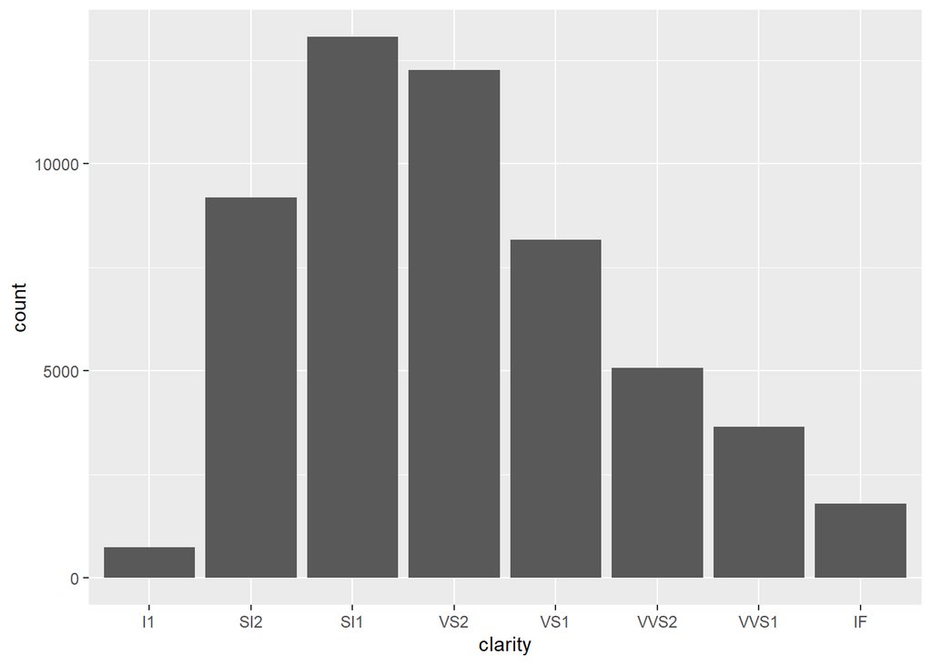

```r
# Add your code here
plot2 <- ggplot(data = diamonds) +
  geom_bar(mapping=aes(x=clarity))
plot2
```

We can also create a bar chart from aggregate data (i.e. we have already got a count of the number of cases). The following chunk creates a small data frame (the number of students on different programmes) and then creates a bar chart using the count of students in each programme. Note that to do this, we need to add ‘stat=“identity”’ to our command.

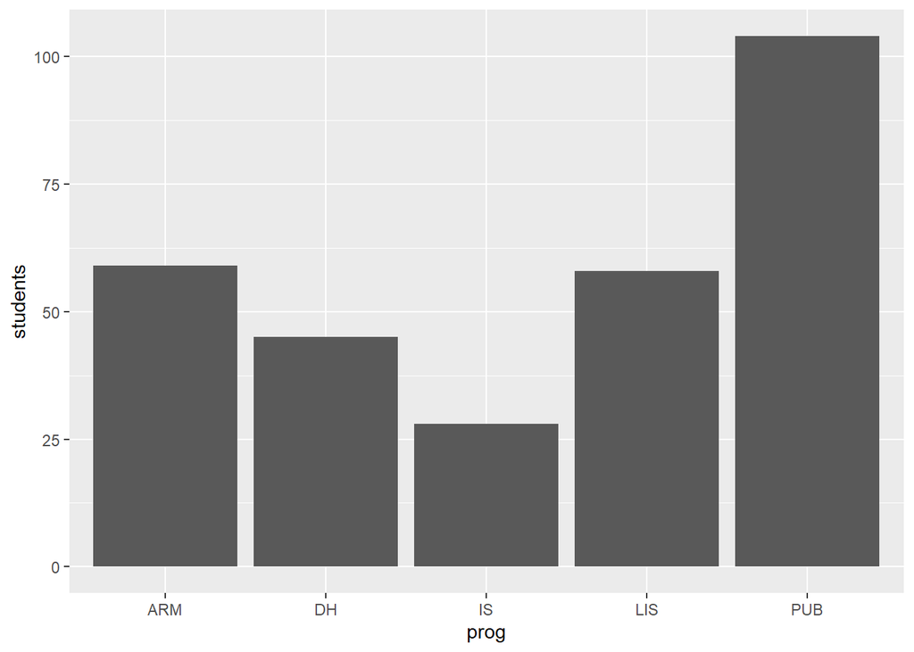

```r
df1 <- data.frame(prog=c("ARM","DH","IS","LIS","PUB"),students=c(59,45,28,58,104))
plot2 <- ggplot(data = df1) +
  geom_bar(mapping=aes(x=prog,y=students),stat="identity")
plot2
```

Often we might have data that has a pre-calculated count like this.

## Using colour

We can tell R to colour each bar separately.

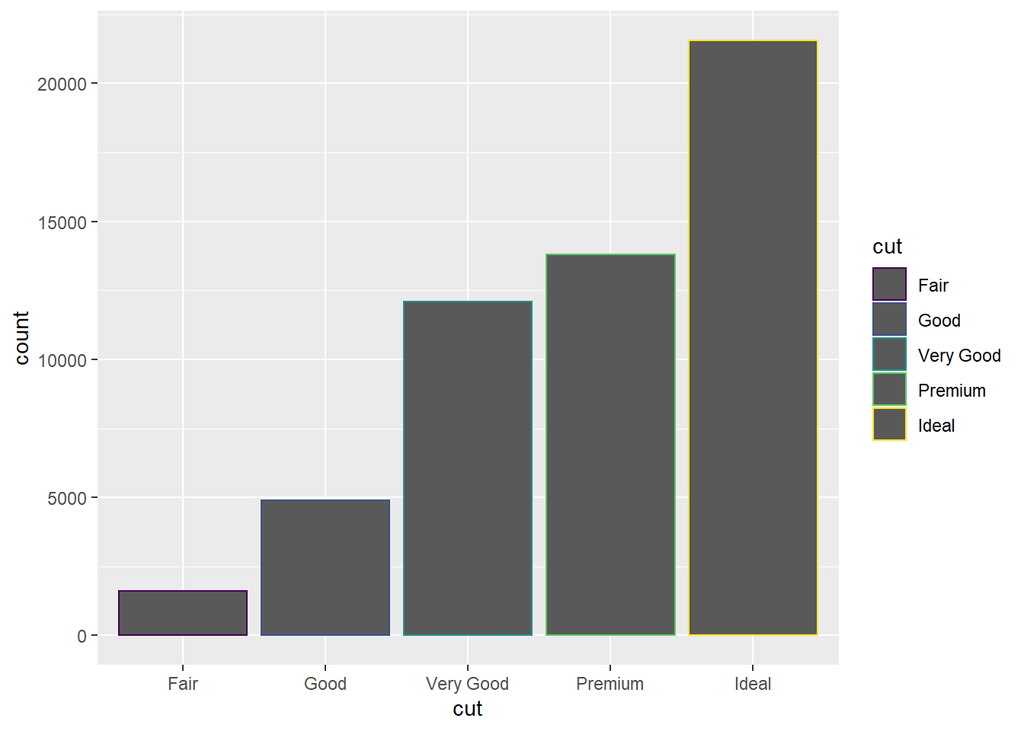

```r
plot3 <- ggplot(data = diamonds) + geom_bar(mapping=aes(x=cut,colour=cut))
plot4 <- ggplot(data = diamonds) + geom_bar(mapping=aes(x=cut,fill=cut))
plot3
```

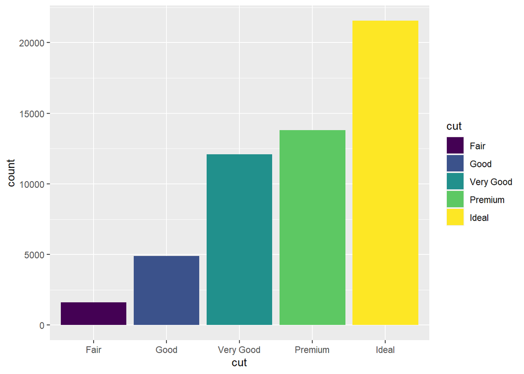

```r
plot4
```

What is the difference between these?

Now, what if we want to colour all the bars together? The above examples focus on the aesthetic - what happens to each category. We can also add colour and fill commands at the *layer* level - these then apply to all elements. We name a specific colour here, because it doesn’t make sense to name a variable which has multiple values across the layer.

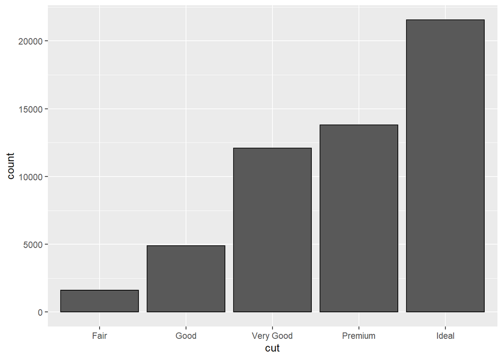

```r
plot5 <- ggplot(data = diamonds) + geom_bar(mapping=aes(x=cut),colour="black")
plot6 <- ggplot(data = diamonds) + geom_bar(mapping=aes(x=cut),fill="blue")
plot5
```

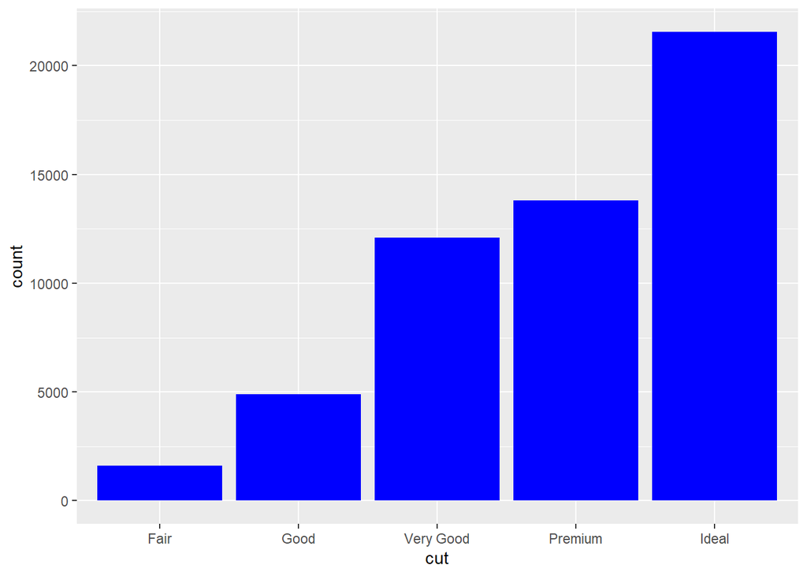

```r
plot6
```

We can mix colour options at both the category and layer level.